# ESM206 Assignment 5

Residual standard error: 22710 on 389 degrees of freedom Multiple R-squared: 0.4478, Adjusted R-squared: 0.4379 F-statistic: 45.07 on 7 and 389 DF, p-value: < 2.2e-16

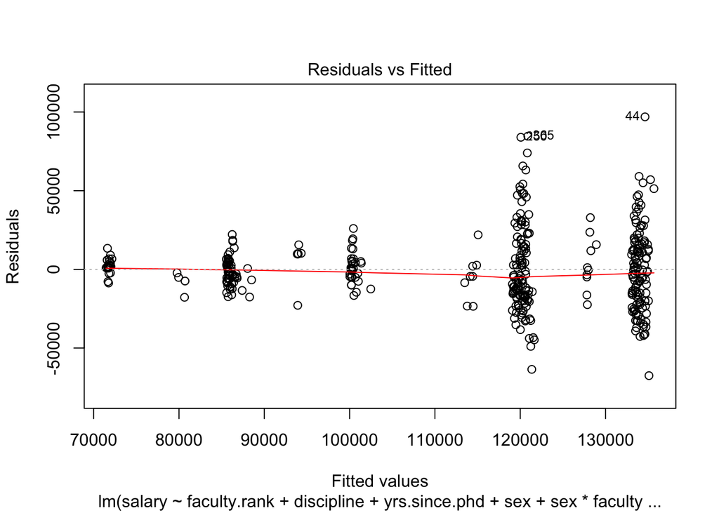

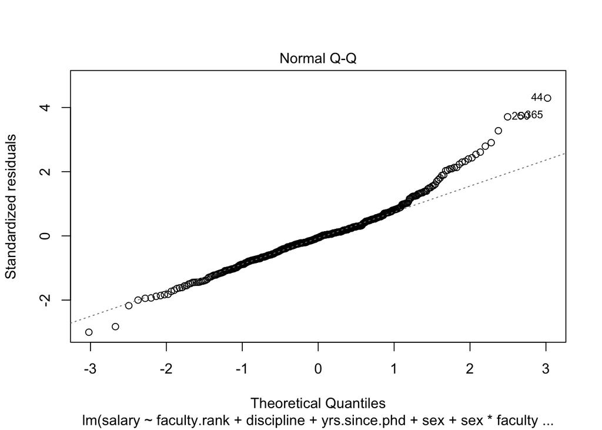

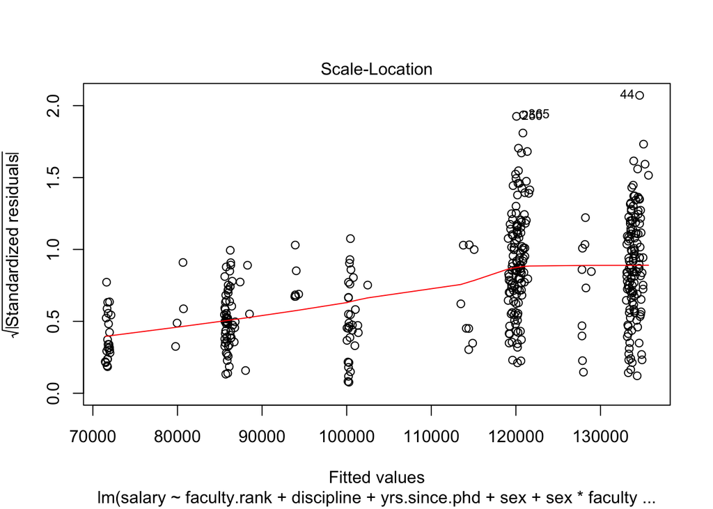

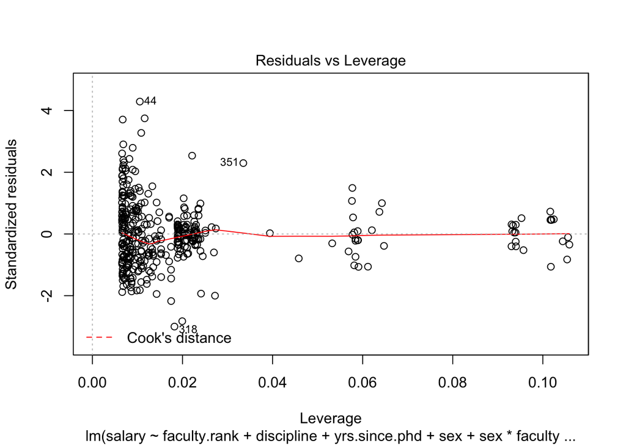

```r
plot(salary_lm3)
```

```r
# taking out yrs.since.phd and keeping yrs.service
salary_lm4<- lm (salary~discipline+yrs.service+sex, data= salary_data)

AIC(salary_lm4) # 9257.162
```

[1] 9257.162

```r
vif(salary_lm4) # all < 4
```

discipline yrs.service sex 1.028760 1.053649 1.025117

```r
summary(salary_lm4)
```

Call: lm(formula = salary ~ discipline + yrs.service + sex, data = salary_data)

Residuals: Min 1Q Median 3Q Max -77424 -19404 -4635 15539 105391

Residual standard error: 27790 on 393 degrees of freedom Multiple R-squared: 0.1646, Adjusted R-squared: 0.1582 F-statistic: 25.81 on 3 and 393 DF, p-value: 2.928e-15

```r
stargazer(salary_lm1, salary_lm2, salary_lm3, type = "html")
```

|  | *Dependent variable:* |  |  |
| --- | --- | --- | --- |
|  | salary |  |  |
|  | (1) | (2) | (3) |
| sexMale | 4,783.493 | 4,349.366 | 6,464.051 |
|  | (3,858.668) | (3,875.393) | (7,817.858) |
| faculty.rankAsstProf:sexMale |  |  | -6,308.131 |
|  |  |  | (10,839.480) |
| faculty.rankProf:sexMale |  |  | -874.006 |
|  |  |  | (9,603.828) |
| faculty.rankAsstProf | -12,907.590*** | -13,104.150*** | -7,848.084 |
|  | (4,145.278) | (4,167.315) | (10,016.190) |
| faculty.rankProf | 32,158.410*** | 32,928.400*** | 33,599.530*** |
|  | (3,540.647) | (3,544.403) | (9,015.904) |
| disciplineB | 14,417.630*** | 13,937.470*** | 14,028.240*** |
|  | (2,342.875) | (2,346.534) | (2,355.315) |
| yrs.since.phd | 535.058** | 61.011 | 58.228 |
|  | (240.994) | (127.010) | (127.640) |
| yrs.service | -489.516** |  |  |
|  | (211.938) |  |  |
| Constant | 78,862.820*** | 80,988.470*** | 79,193.330*** |
|  | (4,990.326) | (4,931.844) | (7,654.839) |
| Observations | 397 | 397 | 397 |
| R<sup>2</sup> | 0.455 | 0.447 | 0.448 |
| Adjusted R<sup>2</sup> | 0.446 | 0.440 | 0.438 |
| Residual Std. Error | 22,538.650 (df = 390) | 22,663.240 (df = 391) | 22,708.750 (df = 389) |
| F Statistic | 54.195*** (df = 6; 390) | 63.266*** (df = 5; 391) | 45.071*** (df = 7; 389) |
| *Note:* | p<0.1; p<0.05; p<0.01 |  |  |